# data_621_hw_3

## Part IV : Select Models

```r
# set threshold
optCutOff <- 0.5

# prediction for each model
predicted_1 <- list(predict(fullModel, test, type = "response"))
predicted_2 <- list(predict(fullModelSqrt, test, type = "response"))
predicted_3 <- list(predict(stepModel, test, type = "response"))
predicted_4 <- list(predict(kFoldModel, test, type = "raw"))
predictions <- list(predicted_1, predicted_2, predicted_3, predicted_4)

# diagnostic - Confusion Matrix, i.e. the columns are actuals, while rows are predicteds
cm_1 <- InformationValue::confusionMatrix(test$target, predicted = predicted_1 %>% unlist, threshold = optCutOff)
cm_2 <- InformationValue::confusionMatrix(test$target, predicted = predicted_2 %>% unlist, threshold = optCutOff)
cm_3 <- InformationValue::confusionMatrix(test$target, predicted = predicted_3 %>% unlist, threshold = optCutOff)
cm_4 <- ftable(predicted_4 %>% unlist, test$target)

cm_1
```

```
##    0  1
## 0 63  8
## 1  8 61
```

```r
cm_2
```

```
##    0  1
## 0 32 47
## 1 39 22
```

```r
cm_3
```

```
##    0  1
## 0 62 12
## 1  9 57
```

```r
cm_4
```

```
##     0  1
##
## 0  62 12
## 1   9 57
```

```r
# diagnostic - AUROC, misClassification, precision, sensitivity, specificity
modelResultList <- vector(mode = "list", length = 3)
names(modelResultList) <- c("full", "full - sqrt transformed", "stepwise")

for(i in 1:length(modelResultList)){

        # metrics
        auroc <- InformationValue::AUROC(test$target, predictions[[i]] %>% unlist)
        misCE <- InformationValue::misClassError(test$target, predictions[[i]] %>% unlist, threshold = optCutOff)
        pre <- InformationValue::precision(test$target, predictions[[i]] %>% unlist, threshold = optCutOff)
        sen <- InformationValue::sensitivity(test$target, predictions[[i]] %>% unlist, threshold = optCutOff)
        spe <- InformationValue::specificity(test$target, predictions[[i]] %>% unlist, threshold = optCutOff)
        cm <- InformationValue::confusionMatrix(test$target, predictions[[i]] %>% unlist, threshold = optCutOff)
        TN <- cm[1, 1]
        FN <- cm[1, 2]
        FP <- cm[2, 1]
        TP <- cm[2, 2]

        # diagnostic output
        tempList <- list(
                data.frame(model = names(modelResultList)[i],
                           auroc = round(auroc, 2),
                           misClass = round(misCE, 2),
                           precision = round(pre, 2),
                           sensitivity = round(sen, 2),
                           specificity = round(spe, 2),
                           `True Positive` = TP,
                           `True Negative` = TN,
                           `False Positive` = FP,
                           `False Negative` = FN,
                           accuracy = round((TP + TN) / (TP + TN + FP + FN), 2),
                           F1 = round(2 * ((pre * sen) / (pre + sen)), 2))
        )

        # put together
        modelResultList <- c(modelResultList, tempList)

}

modelResultDf <- modelResultList %>% dplyr::bind_rows()
## Warning in bind_rows_(x, .id): binding character and factor vector, coercing
## into character vector

## Warning in bind_rows_(x, .id): binding character and factor vector, coercing
## into character vector
modelResultDf %>% kableExtra::kable()
```

| model | auroc | misClass | precision | sensitivity | specificity | True.Positive | True.Negative | False.Positive | False.Negative | accuracy | F1 |
| --- | --- | --- | --- | --- | --- | --- | --- | --- | --- | --- | --- |
| full | 0.97 | 0.11 | 0.88 | 0.88 | 0.89 | 61 | 63 | 8 | 8 | 0.89 | 0.88 |
| full - sqrt transformed | 0.35 | 0.61 | 0.36 | 0.32 | 0.45 | 22 | 32 | 39 | 47 | 0.39 | 0.34 |
| stepwise | 0.96 | 0.15 | 0.86 | 0.83 | 0.87 | 57 | 62 | 9 | 12 | 0.85 | 0.84 |

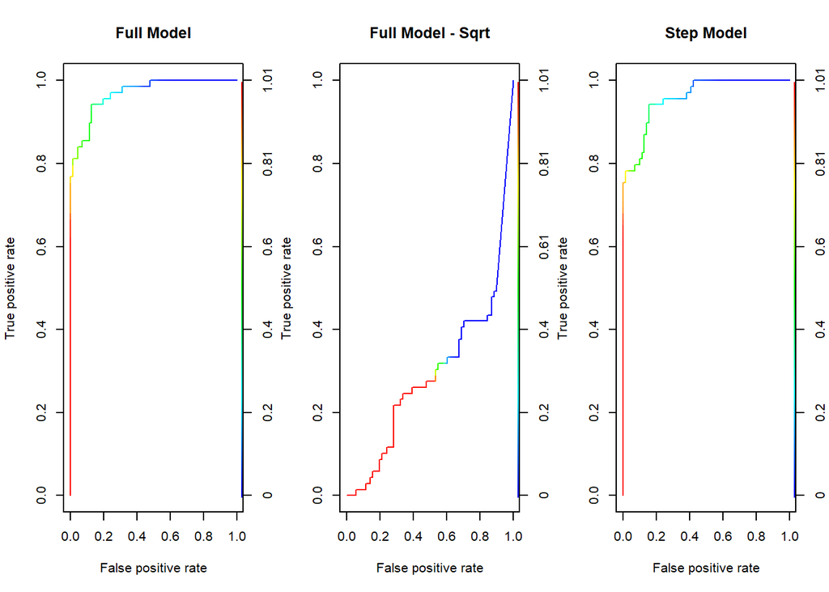

```r
# ROC Curve
par(mfrow = c(1, 3))
pred <- prediction(predicted_1 %>% unlist, test$target)
perf <- performance(pred, "tpr", "fpr")
plot(perf, colorize = TRUE, main = "Full Model")

pred <- prediction(predicted_2 %>% unlist, test$target)
perf <- performance(pred, "tpr", "fpr")
plot(perf, colorize = TRUE, main = "Full Model - Sqrt")

pred <- prediction(predicted_3 %>% unlist, test$target)
perf <- performance(pred, "tpr", "fpr")
plot(perf, colorize = TRUE, main = "Step Model")
```

```r
# Final print of the stepModel
tidy(stepModel)
```

```
## # A tibble: 9 x 5
##   term         estimate std.error statistic      p.value
##   <chr>           <dbl>     <dbl>     <dbl>        <dbl>
## 1 (Intercept) -34.8       6.60        -5.28 0.000000130
## 2 zn           -0.0832    0.0405      -2.06 0.0397
## 3 nox          43.1       7.78         5.54 0.0000000307
## 4 dis           0.537     0.248        2.17 0.0304
## 5 rad           0.720     0.173        4.16 0.0000315
## 6 tax          -0.00787   0.00353     -2.23 0.0258
## 7 ptratio       0.257     0.124        2.07 0.0389
## 8 lstat         0.0836    0.0533       1.57 0.117
## 9 medv          0.131     0.0496       2.65 0.00813
```

```r
# Prediction for Evaluation Set
dfEval <- dfEval %>%
        dplyr::mutate(prediction = predict(stepModel, dfEval, type = "response"),
                      prediction = ifelse(prediction > optCutOff, 1, 0))
table(dfEval$prediction)
```

```
##
##  0  1
## 18 22
```

*** Above results indicated that approach 3 and 4 (stepModel, kFoldModel) shared the identical confusion matrix. Essentially, they are not different, thus we removed it from the for() loop for comparison. Surprisingly, the fullModel is slightly better than the stepModel in terms of area under the ROC curve, less misclassification error, more sensitive and accurate and so forth. However, we decide to go with the stewpwise approach because the model is more elegant and trim off irrelevant variables and that became more parsimonious.